# Spatial Autocorrelation for Categorical Variables

## The Join Count Statistic

#### We have seen in previous lectures that Moran’s I can be used to assess spatial autocorrelation in continuous variables. However, what do you do when the variable of interest is categorical and you’re dealing with a polygon shapefile? (Methods presented here are based on spatial contiguity and aren’t suitable for point data or non-contiguous polygons, although there may be ways to adapt them to problems of the sort.)

#### Let’s look at what spatial autocorrelation would look like with a binary variable. Let’s take a 6x6 grid as an example (there are a total of 36 cells, or blocks). Below, we have 3 patterns – one with positive spatial autocorrelation, one with negative spatial autocorrelation, and one with no spatial autocorrelation (i.e., a random pattern). For a Queen weight matrix, there are 110 total joins (borders) between the 36 blocks, but we can also calculate how many joins (i.e., boundaries) black blocks share with other black blocks (J<sub>BB</sub>), white blocks share with other white blocks (J<sub>WW</sub>), and black blocks share with white blocks (J<sub>WB</sub>).

#### Below is an example of **Positive Spatial Autocorrelation**. We can calculate that J<sub>BB</sub> = 47, J<sub>WW</sub> = 47, and J<sub>BW</sub> = 16.

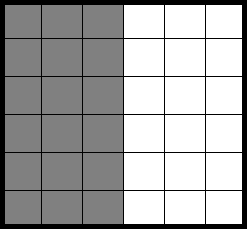

#### Below is an example of **Negative Spatial Autocorrelation**. We can calculate that J<sub>BB</sub> = 25, J<sub>WW</sub> = 25, and J<sub>BW</sub> = 60.

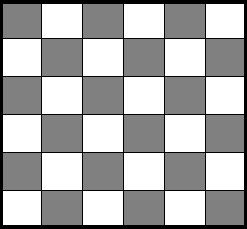

#### Below is an example of **No Spatial Autocorrelation**. We can calculate that J<sub>BB</sub> = 14, J<sub>WW</sub> = 40, and J<sub>BW</sub> = 56.

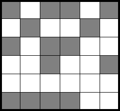

#### Based on what we see above, we can say that we have:

#### **Positive spatial autocorrelation** (i.e., clustering) if the numbers of BB and WW joins are significantly higher than what we would expect by chance (or, said differently, the number of BW joins is significantly lower than what we would expect by chance)

#### **Negative spatial autocorrelation** (i.e., dispersion) if the numbers of BB and WW joins are significantly lower than what we would expect by chance (or, said differently, the number of BW joins is significantly higher than what we would expect by chance)

#### **No spatial autocorrelation** (i.e., random pattern) if the numbers of BB and WW joins are approximately the same as what we would expect by chance (or, said differently, the number of BW joins is approximately the same as what we would expect by chance)

#### Now, let’s look at the expected counts of the BB, WW and BW joins under the null hypothesis of no spatial autocorrelation.

#### The *expected count* of the BB join is:

$$E(J_{BB}) = kP^2_B$$

#### The *expected count* of the WW join is:

$$E(J_{WW}) = kP^2_W$$

#### The *expected count* of the BW join is:

$$E(J_{BW}) = 2kP_BP_W$$

#### The formulae for the corresponding standard errors are below:

$$\sigma(J_{BB})= \sqrt {kP^2_B + 2mP^3_B - (k+2m)P^4_B}$$

$$\sigma(J_{WW})= \sqrt {kP^2_W + 2mP^3_W - (k+2m)P^4_W}$$

$$\sigma(J_{BW})= \sqrt {2(k+m)P_B P_W - 4(k+2m)P^2_B P^2_W}$$

#### In the formulae above, *k* is the total numer of joins (boundaries), P<sub>B</sub> is the expected proportion of black blocks under randomness, P<sub>W</sub> is the expected proportion of white blocks under randomness, and

$$m=1/2\sum_{i}^{n} k_{i}(k_{i}-1).$$

#### Ultimately, if we take the *observed count* of the BB join, subtact from it the *expected count* of the BB join, and divide that difference by the standard deviation of the BB join, the resulting statistic follows an (asymptotically) standard normal distribution under the null hypothesis of no clustering. Similarly, if we take the *observed count* of the WW join, subtact from it the *expected count* of the WW join, and divide that difference by the standard deviation of the WW join, the resulting statistic follows an (asymptotically) standard normal distribution under the null hypothesis of no clustering.

#### Said differently,

$$\frac{J_{BB} - E(J_{BB})}{\sigma_{J_{BB}}} \sim Z$$

#### and

$$\frac{J_{WW} - E(J_{WW})}{\sigma_{J_{WW}}} \sim Z$$